# Week 4

E

3/2/2021

# Multiple Linear Regression

[figure not shown]

Where we have multiple continuous explanatory variables

$$y_i = beta_0 + beta_1X_{1i} + beta_2X_{2i} + e_i$$
$beta_0$ is the intercept

$beta_1$ is the slope of the $X_1$ relationship

- The change in Yi with on eunit change in $X_1$ at *any* value of $X-2$ (*additive model*)

$beta_2$ is the slope of the $X_2$ relationship

- The chnage in Yi withone unit change in $X_2$ at *any* value of $X-1$ (*additive model*)

> The changes in Yi with the change in one explanatory variable while the other(s) held constant are often called: *marginal effects*

### Lets go through an example. –> Indigo Snakes

```r
indigos <- read.table(file = "indigosMLR.txt", header = TRUE)

indigos$log.HR <- log(indigos$hr.size)
str(indigos)
```

```
## 'data.frame':    92 obs. of  5 variables:
##  $ hr.size    : num  67.3 45.1 165.3 358.7 160.1 ...
##  $ urban1.50  : num  0.36 0 0.01 0.06 0 0.3 0.08 0 0.6 0.01 ...
##  $ upland1.50 : num  0.17 0.67 0.67 0.6 0.55 0.23 0.4 0.3 0.24 0.47 ...
##  $ wetland1.50: num  0.45 0.35 0.24 0.35 0.46 0.4 0.49 0.66 0.12 0.49 ...
##  $ log.HR     : num  4.21 3.81 5.11 5.88 5.08 ...
```

We are interested in the variation in home range sizes of snakes (`hr.size`) based on what their home ranges are made up of. We log transformed the home range data (`log.HR`). Our proposed covariates are surround habitat structure (proportion). They are the proportion of a 1.5 km radius circle around the nesting site.

- `Urban1.50`
- `Upland1.50`
- `Wetland1.50`

Recall the modeling process

```
Modeling Process:

1. State the question/Hypothesis
    * What are the questions?
    * What are the variables?

2. Data Exploration

3. Describe the model
    * In word form
    * In mathematical form
    * Identify the assumptions of the model

4. Fit the model

5. Evaluate the output
    * Model validation
    * Model Selection

6. Interpret the results
```

#### State the question/Hypothesis

Question: Does habitat compostion at the home range scale explain variation in home range size?

$H_0$: There is no relationship between home range size and habitat composition

Variables:

- Response
  - Home range
- Explanatory:
  - Urban Percent
  - Upland percent
  - Wetland percent

#### Data Exploration

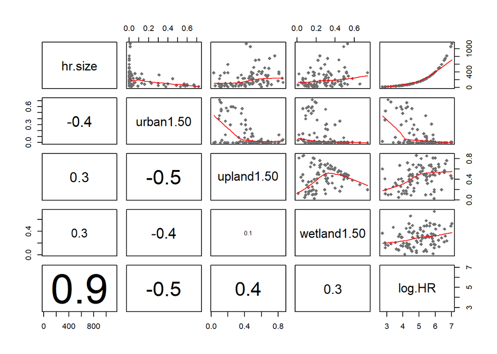

```r
panel.cor <- function(x, y, digits=1, prefix="", cex.cor)
{
    usr <- par("usr"); on.exit(par(usr))
    par(usr = c(0, 1, 0, 1))
    r1=cor(x,y,use="pairwise.complete.obs")
    r <- abs(cor(x, y,use="pairwise.complete.obs"))

    txt <- format(c(r1, 0.123456789), digits=digits)[1]
    txt <- paste(prefix, txt, sep="")
    if(missing(cex.cor)) cex <- 0.9/strwidth(txt)
    text(0.5, 0.5, txt, cex = cex * r)
}


panel.smooth<-function (x, y, col = "grey44", bg = NA, pch = 18, cex = 1, col.smooth = "red", span = 2/3, iter = 3, ...)
{
  points(x, y, pch = pch, col = col, bg = bg, cex = cex)
  ok <- is.finite(x) & is.finite(y)
  if (any(ok))
    lines(stats::lowess(x[ok], y[ok], f = span, iter = iter),
          col = col.smooth, ...)
}

pairs(indigos,
      upper.panel = panel.smooth, lower.panel = panel.cor)
```

#### Describe the Model

In Workds

- Does habitat compostion at the home range scale explain variation in home range size?

As a mathematical model:

$y_i$ = $beta_0 + beta_1X_{urbi}$ + $beta_2X_{upi} + beta_3X_{weti} + e_i$

$H_0$: $beta_1$ = 0, $beta_2$ = 0, $beta_3$ = 0

Assumptions?

- Residuals are normally distributed
- Constant variance (homogeneity)
- Observations are independent
- Predictors measured without error (fixed X)

#### Fit the Model

```r
mG <- lm(log.HR ~ urban1.50 + upland1.50 + wetland1.50, data = indigos)

summary(mG)
```

```
##
## Call:
## lm(formula = log.HR ~ urban1.50 + upland1.50 + wetland1.50, data = indigos)
##
## Residuals:
##      Min       1Q   Median       3Q      Max
## -2.63249 -0.52193  0.06665  0.59191  1.69868
##
## Coefficients:
##             Estimate Std. Error t value Pr(>|t|)
## (Intercept)   4.6091     0.3502  13.160  < 2e-16 ***
## urban1.50    -1.8465     0.5392  -3.424 0.000938 ***
## upland1.50    0.9171     0.4999   1.835 0.069945 .
## wetland1.50   0.6711     0.6086   1.103 0.273153
## ---
## Signif. codes:  0 '***' 0.001 '**' 0.01 '*' 0.05 '.' 0.1 ' ' 1
##
## Residual standard error: 0.8476 on 88 degrees of freedom
## Multiple R-squared:  0.3091, Adjusted R-squared:  0.2855
## F-statistic: 13.12 on 3 and 88 DF,  p-value: 3.694e-07
```

We notice that the slope between percent urban in the home range and home range size is significantly negative. The other two variables do not seem to have a significant difference in home range size.

#### Evaluate the output

Lets check the assumptions

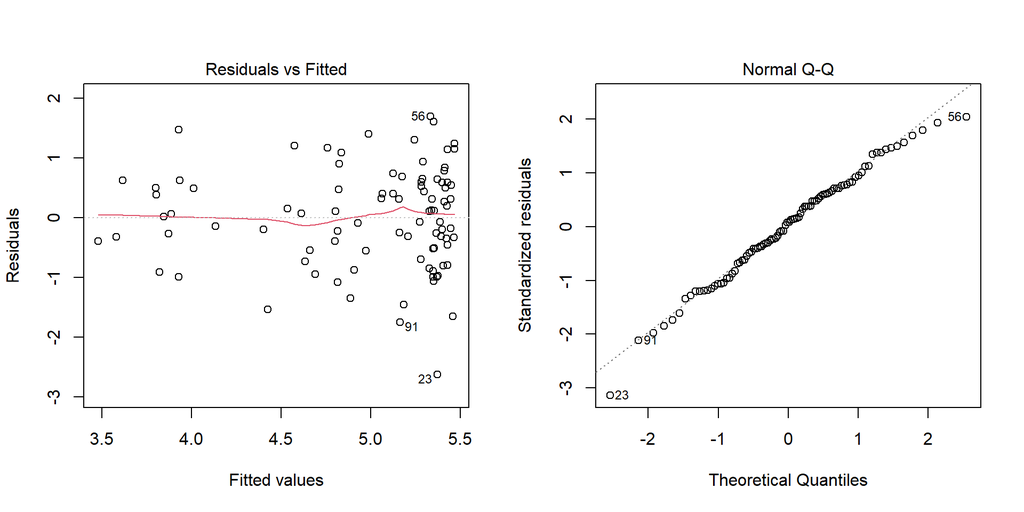

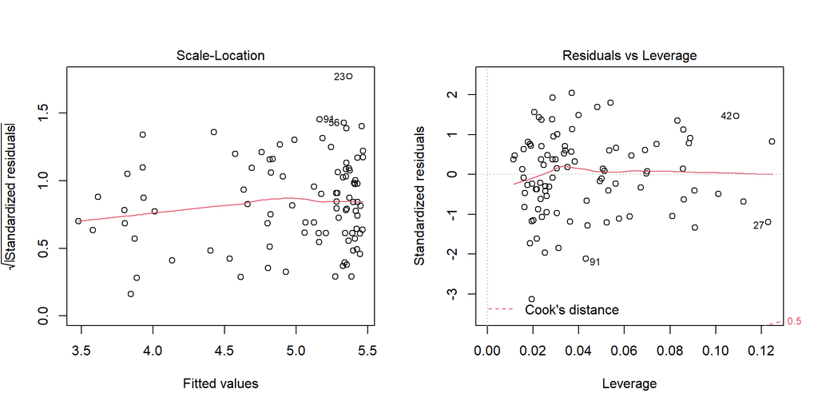

```r
par(mfrow = c(1,2))
plot(mG)
```

We look pretty good on our assumptions

Lets select our model.

The other candidate models are:

- Full (global) model: $y_i = beta_0 + beta_1X_{urbi} + beta_2X_{upi} + beta_3X_{weti} + e_i$
- Single Predictor models:
  - $y_i = beta_0 + beta_1X_{urbi} + ei$
  - $y_i = beta_0 + beta_2X_{upi} + ei$
  - $y_i = beta_0 + beta_3X_{weti} + ei$
- Null Model: $y_i = beta_0 + e_i$
- Combination Models:
  - $y_i = beta_0 + beta_1X_{urbi} + beta_2X_{upi} + ei$
  - $y_i = beta_0 + beta_1X_{urbi} + beta_3X_{weti} + ei$
  - $y_i = beta_0 + beta_2X_{upi} + beta_3X_{weti} + ei$

What may be the best model

```r
UrUpWe <- lm(log.HR ~ urban1.50 + upland1.50 + wetland1.50, data = indigos)
UrUp <- lm(log.HR ~ urban1.50 + upland1.50, data = indigos)
UrWe <- lm(log.HR ~ urban1.50 + wetland1.50, data = indigos)
UpWe <- lm(log.HR ~ upland1.50 + wetland1.50, data = indigos)
Ur <- lm(log.HR ~ urban1.50, data = indigos)
Up <- lm(log.HR ~ upland1.50, data = indigos)
We <- lm(log.HR ~ wetland1.50, data = indigos)
m0 <- lm(log.HR ~ 1, data = indigos)

## Put them to a fit list and use AIC
fitList <- list(
  UrUpWe = lm(log.HR ~ urban1.50 + upland1.50 + wetland1.50, data = indigos),
UrUp = lm(log.HR ~ urban1.50 + upland1.50, data = indigos),
UrWe = lm(log.HR ~ urban1.50 + wetland1.50, data = indigos),
UpWe = lm(log.HR ~ upland1.50 + wetland1.50, data = indigos),
Ur = lm(log.HR ~ urban1.50, data = indigos),
Up = lm(log.HR ~ upland1.50, data = indigos),
We = lm(log.HR ~ wetland1.50, data = indigos),
m0 = lm(log.HR ~ 1, data = indigos)
)
(modtab <-  aictab(fitList))
```

```
##
## Model selection based on AICc:
##
##        K   AICc Delta_AICc AICcWt Cum.Wt      LL
## UrUp   4 236.29       0.00   0.38   0.38 -113.91
## Ur     3 237.15       0.87   0.25   0.63 -115.44
## UrUpWe 5 237.26       0.98   0.24   0.87 -113.28
## UrWe   4 238.48       2.19   0.13   1.00 -115.01
## UpWe   4 246.53      10.25   0.00   1.00 -119.04
## Up     3 250.30      14.01   0.00   1.00 -122.01
## We     3 259.50      23.21   0.00   1.00 -126.61
## m0     2 264.72      28.43   0.00   1.00 -130.29
```

```r
summary(UrUp)
```

```
##
## Call:
## lm(formula = log.HR ~ urban1.50 + upland1.50, data = indigos)
##
## Residuals:
##      Min       1Q   Median       3Q      Max
## -2.59312 -0.64147  0.03546  0.59221  1.83352
##
## Coefficients:
##             Estimate Std. Error t value Pr(>|t|)
## (Intercept)   4.8548     0.2706  17.941  < 2e-16 ***
## urban1.50    -2.0704     0.5001  -4.140 7.89e-05 ***
## upland1.50    0.8634     0.4981   1.733   0.0865 .
## ---
## Signif. codes:  0 '***' 0.001 '**' 0.01 '*' 0.05 '.' 0.1 ' ' 1
##
## Residual standard error: 0.8486 on 89 degrees of freedom
## Multiple R-squared:  0.2996, Adjusted R-squared:  0.2838
## F-statistic: 19.03 on 2 and 89 DF,  p-value: 1.316e-07
```

We notice that the urban sites have a negative relationship with the home range size. It is significantly different.

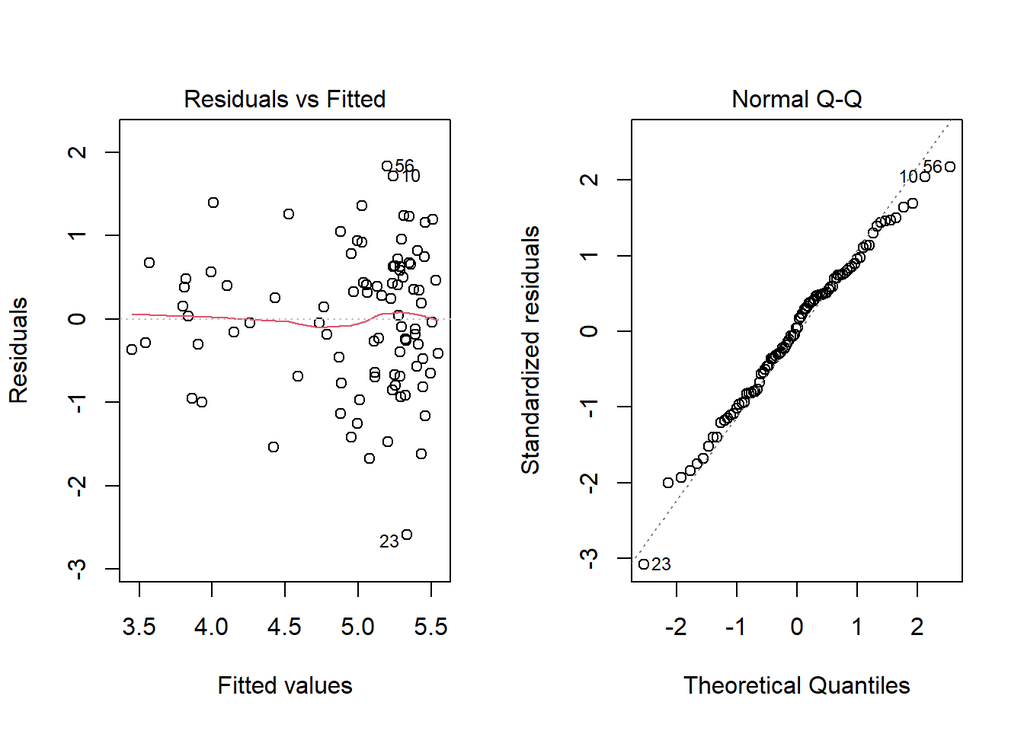

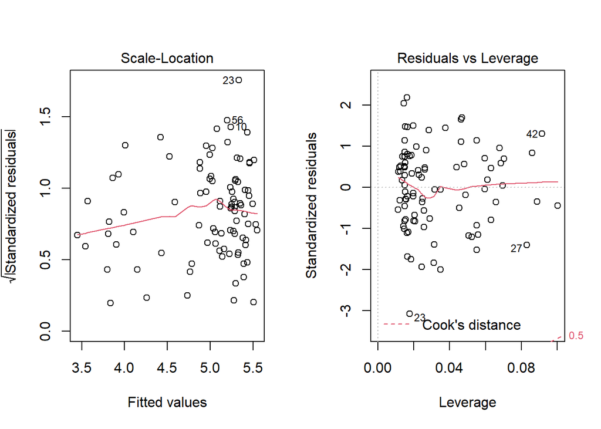

```r
par(mfrow = c(1,2))
plot(UrUp)
```